# Teste para normalidade e homocedasticidade

# Teste de normalidade

A suposição de normalidade dos dados amostrais é uma condição exigida para a realização de muitas inferências válidas a respeito de parâmetros populacionais. Vários dos diferentes métodos de estimação e testes de hipóteses existentes foram formulados sob a suposição de que a amostra aleatória tenha sido extraída de uma população gaussiana.

Neste material vamos apresentar alguns testes que nos permitem verificar essa suposição. Também é importante salientar que além deles é fundamental observar a distribuição empírica dos dados por exemplo através do gráfico de densidade.

Será apresentados alguns exemplos resolvidos com o *R*. É fortemente sugerido a leitura das referências ao final deste matrial para melhor compreensão de cada teste apresentado.

## Teste de Shapiro Wilk.

Aqui, para fins didáticos, vamos gerar uma amostra de tamanho 100 de uma variável aleatória $X \sim N(\mu=1, \sigma^2=0.16)$. Neste caso a hipótese a ser testada é se os dados seguem uma distribuição gaussiana.

$H_0:$ Os dados seguem uma distribuição gaussiana.

```r
######### criando um vetor
set.seed(123399)
x <- rnorm(100,1,.4)

######### Teste de Shapiro Wilks

shapiro.test(x)
```

```
    Shapiro-Wilk normality test

data:  x
W = 0.99326, p-value = 0.9032
```

Agora vamos verificar o gráfico de densidade da amostra.

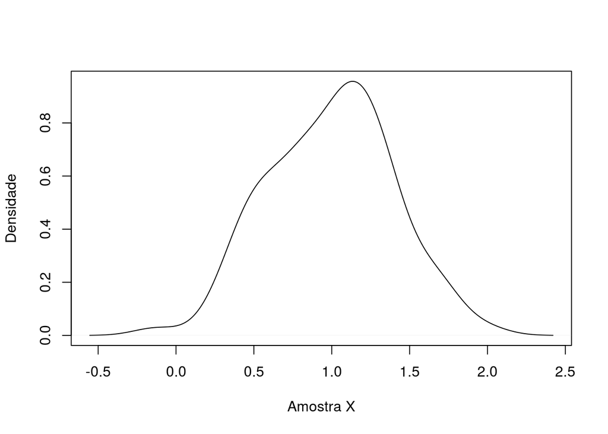

```r
plot(density(x), ylab='Densidade', xlab='Amostra X', main='')
```

Realmente a amostra parece seguir uma distribuição gaussiana.

## Teste Anderson-darling

Próximo teste a ser explorado é o de **Anderson-darling**. Para isso precisamos instalar no *R* o pacote `nortest` para usar a função `ad.test()`. Aqui vamos usar a mesma amostra do exercício anterior e será testada a mesma hipótese:

$H_0:$ Os dados seguem uma distribuição gaussiana.

```r
#install.packages('nortest',repos='http://cran-r.c3sl.ufpr.br/')
library(nortest)
ad.test(x)
```

```
    Anderson-Darling normality test

data:  x
A = 0.26261, p-value = 0.6959
```

Aqui também não rejeitamos a hipótese que os dados seguem uma distribuição gaussiana.

## Teste Cramer-von Mises

O teste de Cramer-von Mises também necessita do pacote `nortest` para aplicar a função `cvm.test()` e novamente testamos:

$H_0:$ Os dados seguem uma distribuição gaussiana.

```r
cvm.test(x)
```

```
    Cramer-von Mises normality test

data:  x
W = 0.042458, p-value = 0.6324
```

## Teste Lilliefors

$H_0:$ Os dados seguem uma distribuição gaussiana. Utilizando a função `lillie.test()` do mesmo pacote.

```r
lillie.test(x)
```

```
    Lilliefors (Kolmogorov-Smirnov) normality test

data:  x
D = 0.053479, p-value = 0.6869
```

E evidentemente para os testes de Lilliefors e Cramer-vos Mises, não rejeitamos a hipótese que os dados seguem uma distribuição gaussiana.

## Teste de Kolmogorov-Smirnov

Este é um dos mais populares na Estatística. Ele tem o intuito de verificar se uma amostra tem aderência a uma determinada distribuição de probabilidade ou comparar duas distrições. A idéia por trás do teste é a comparação da função de distribuição empírica $F(x)$ com uma função de ditribuição teórica, ou a comparação entre duas $F(x)'s$ e verificar a distância entre as funções de distribuição.

Abaixo um exemplo comparando a mesma amostra aleatória anteior com a função de distribuição gaussiana.

```r
  sd(x)
```

```
[1] 0.3977798
```

```r
ks.test(x, "pnorm", 1, .16)
```

```
    One-sample Kolmogorov-Smirnov test

data:  x
D = 0.23032, p-value = 4.934e-05
alternative hypothesis: two-sided
```

Agora vamos comparar duas amostras e testar se ambas possuem distribuições iguais ou não. Para isso vamos gerar uma segunda amostra de mesmos tamanho de $X$, $Y \sim Gamma(\alpha = 1, \beta=4)$

```r
y <- rgamma(100,1, 4)
```

Além do teste Kolmogorov-Smirnov, vamos plotar o gráfico das duas distribuição e indicar a distância entre ambas. Este gráfico pode ser simplesmente chamado de gráfico $KS$.

```r
#===========
#Curva K-S
#===========
library(latticeExtra)
ks.cal <- function(x,lag){
  x <- sort(x); n <- length(x)
  X <- (1/n)*apply(outer(x, lag, function(z,w) z<=w), 2, sum)
  X
}



smir<-ks.test(x,y)
smir
```

```
    Two-sample Kolmogorov-Smirnov test

data:  x and y
D = 0.8, p-value < 2.2e-16
alternative hypothesis: two-sided
```

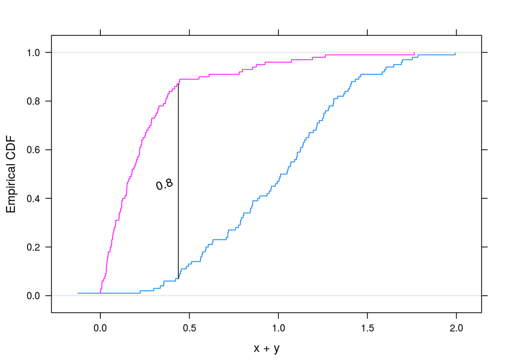

```r
lag <- seq(min(x,y), max(x,y), l=length(unique(c(x,y))))
x.ks <- ks.cal(x, lag)
y.ks <- ks.cal(y, lag)

ks.max <- max(abs(x.ks-y.ks))
lagmax <- lag[which.max(abs(x.ks-y.ks))]
coomax <- which.max(abs(x.ks-y.ks))
abcmax <- c(x.ks[coomax], y.ks[coomax])

ecdfplot(~x+y,
         panel=function(x, ...){
           panel.ecdfplot(x, ...)
           panel.segments(lagmax, abcmax[1], lagmax, abcmax[2])
           panel.text(lagmax, min(abcmax)+ks.max/2, label=ks.max, pos=2, srt=18)
})
```

Notamos que pelo resultado do p-valor do teste, `0`, rejeitamos a hipótese nula, ou seja, há evidências para dizer as duas distribuições são diferentes. Outro indicativo disso é o alto valor da estatística de teste $D=$`0.8`, que indica uma grande distância entre as duas distribuições, como podemos verificar na gráfico.

## Verificação gráfica

Outra forma de vrificar se uma amostra segue uma distribuição gaussiana, é aatravés dos gráfico de envelope normal de probabilidade e seu envelope com intervalo de confiança simulado.

Podemos simplesmente fazer usando as funções `qqnorm()` e `qqline()` sem o envelope:

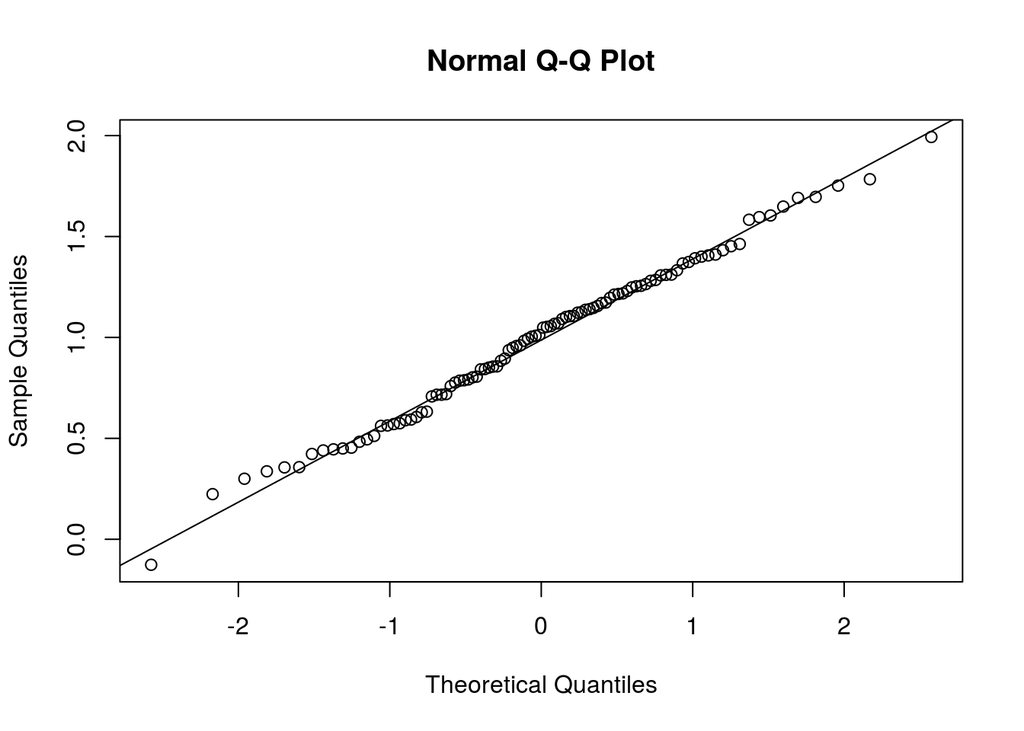

```r
qqnorm(x)
qqline(x)
```

Mas também podemos fazer com o envelope simulado através da função `qqPlot()` do pacote `car`.

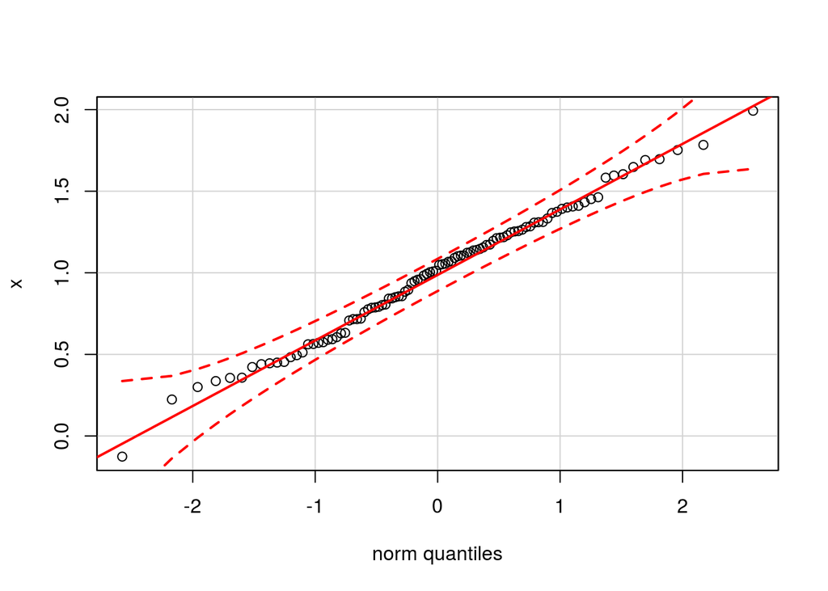

```r
library(car)
qqPlot(x, dist='norm',envelope=.95)
```

Aplicando agora a função `qqPlot()` para a amostra $Y$:

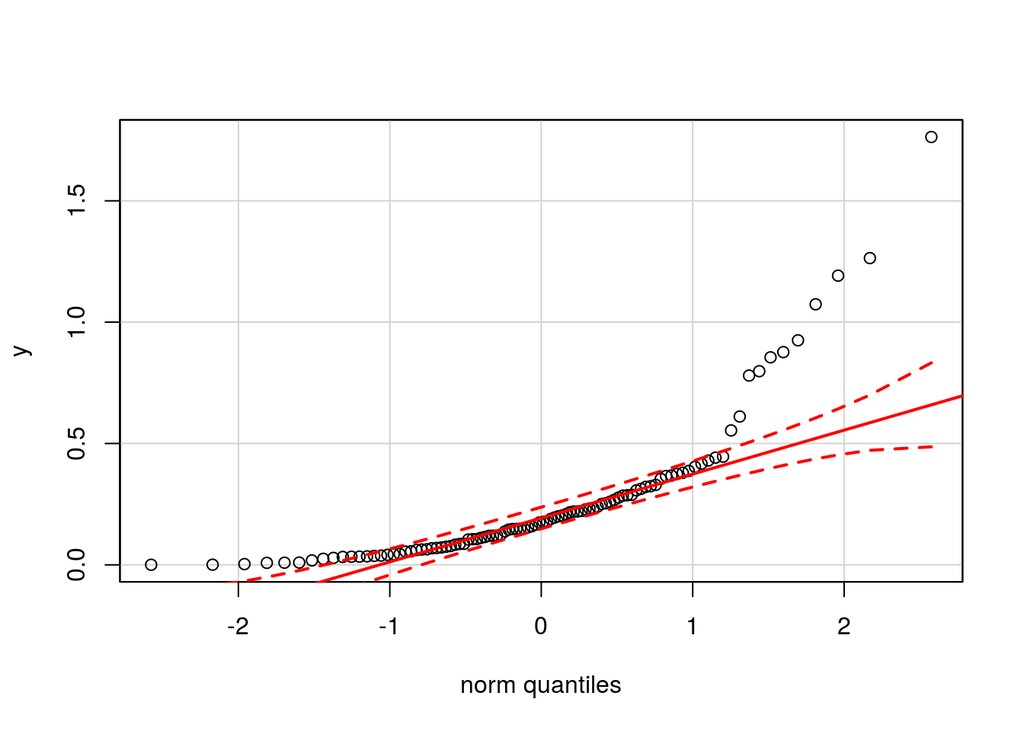

```r
qqPlot(y, dist='norm',envelope=.95)
```

Notamos que para a amostra $Y$, há vários pontos fora da banda do envelope simulado, indicando que há evidências que esta amostra não segue uma distribuição gaussiana, como já se esperava pois sabemos que $Y \sim Gamma(\alpha=1, \beta=4)$.

# Teste de homocedasticidade

Em análise de variância(ANOVA), há um pressuposto que deve ser atendido que é de os erros terem variância comum, ou seja, homocedasticidade. Isso implica que cada tratamento que se está sendo comparado pelo teste *F*, deve ter aproximadamente a mesma variância para que a ANOVA tenha validade. Quando este pressuposto não é atendido dizemos que as variâncias não são homogêneas, ou ainda, que existe **heterocedasticidade**.

A verificação deste pressuposto também pode ser verificado graficamente através do boxplot para os tratamentos *vs* resíduos. Se existir homocedasticidade espera-se que os boxplots sejam semelhantes.

Veja o seguinte exemplo, os dados abaixo são provenientes de um experimento em que se deseja verificar se há diferença entre as práticas parentais com relação a três grupos de crianças. O primeiro grupo são de crianças com síndrome de down, o segundo grupo são de crianças com síndrome de down em que os pais recebem orientção sobre prtáricas parentais para este grupo especial e o terciro grupo de crianças não possuem síndrome de down. Para medir as práticas parentais há um instrumento psicológico que gera um escore em que os resultados estão guardados na variável `PP`.

Primeiro carregamos os dados:

```r
dados<-read.csv2('http://www.leg.ufpr.br/lib/exe/fetch.php/pessoais:total.csv', h=T)
str(dados)
```

```
'data.frame':   120 obs. of  27 variables:
 $ Grupo                   : int  1 1 1 1 1 1 1 1 1 1 ...
 $ SD                      : int  1 1 1 1 1 1 1 1 1 1 ...
 $ DI                      : int  0 0 0 0 0 0 0 0 0 0 ...
 $ Idade_da_crianca        : int  0 0 1 1 0 1 1 0 1 0 ...
 $ sexo                    : int  1 1 1 0 0 0 0 0 1 0 ...
 $ escola                  : int  1 1 1 1 1 1 1 1 1 1 ...
 $ ocupacao_da_mae         : int  1 1 1 3 1 3 1 3 1 1 ...
 $ ocupacao_da_mae_Trabalha: int  1 1 1 0 1 0 1 0 1 1 ...
 $ ocupacao_da_mae_Lar     : int  0 0 0 1 0 1 0 1 0 0 ...
 $ ocupacao_do_pai         : int  1 1 1 1 3 1 1 1 3 1 ...
 $ ocupacao_do_pai_Trabalha: int  1 1 1 1 0 1 1 1 0 1 ...
 $ ocupacao.do_pai_Lar     : int  0 0 0 0 1 0 0 0 1 0 ...
 $ idade_da_mae            : int  34 32 30 32 22 49 48 32 55 27 ...
 $ idade_do_pai            : int  36 36 31 47 25 47 50 50 59 27 ...
 $ situacao_conjugal       : int  3 1 1 3 4 2 1 1 1 1 ...
 $ casado                  : int  0 1 1 0 0 0 1 1 1 1 ...
 $ Numero_de_filhos        : int  2 1 2 1 1 2 2 3 5 2 ...
 $ Tipo_de_moradia         : int  1 0 1 1 1 1 1 1 1 1 ...
 $ Condicao_de_moradia     : int  1 1 1 1 2 1 1 1 1 3 ...
 $ Condicao_de_moradia.1   : int  1 1 1 1 2 1 1 1 1 3 ...
 $ Moradia_Propria         : int  1 1 1 1 0 1 1 1 1 0 ...
 $ Moradia_Alugada         : int  0 0 0 0 0 0 0 0 0 0 ...
 $ media_salarial          : int  5 5 2 2 2 2 6 6 2 2 ...
 $ PP                      : int  171 176 179 179 162 152 160 171 147 177 ...
 $ CP                      : int  171 197 175 201 164 183 203 179 188 208 ...
 $ PSI                     : int  132 124 80 128 107 101 94 103 105 130 ...
 $ FACES_IV                : int  201 200 220 227 222 219 205 233 211 226 ...
```

```r
summary(factor(dados$Grupo))
```

```
 1  2  3
45 41 34
```

Agora vamos ajustar uma ANOVA:

```r
mod<-aov(dados$PP~dados$Grupo)
summary(mod)
```

```
             Df Sum Sq Mean Sq F value Pr(>F)
dados$Grupo   1    262   261.8   1.006  0.318
Residuals   118  30709   260.2
```

Lembrando que estamos testando a hipótese nula das variâncias serem iguais:

$$H_0: \sigma^2_1=\sigma^2_2=\sigma^2_3$$

Aqui vamos apresentar o boxplot e o teste de Bartlett:

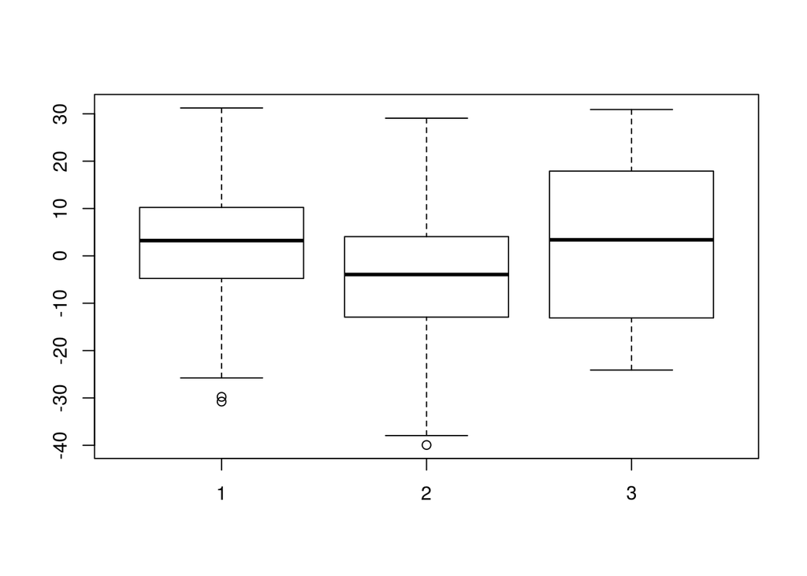

```r
boxplot(mod$res~dados$Grupo)
```

```r
bartlett.test(mod$res~dados$Grupo)
```

```
    Bartlett test of homogeneity of variances

data:  mod$res by dados$Grupo
Bartlett's K-squared = 2.0255, df = 2, p-value = 0.3632
```

Notamos que o teste confirma o que o boxplot nos sugere, homogeneidade das variâncias.

# Referências

- Patrick Royston (1982). An extension of Shapiro and Wilk’s W test for normality to large samples. *Applied Statistics*, *31*, 115-124.
- Patrick Royston (1982). Algorithm AS 181: The W test for Normality. *Applied Statistics*, *31*, 176-180.
- Patrick Royston (1995). Remark AS R94: A remark on Algorithm AS 181: The W test for normality. *Applied Statistics*, *44*,547-551.
- https://cran.r-project.org/web/packages/nortest/nortest.pdf
- Z. W. Birnbaum and Fred H. Tingey (1951), One-sided confidence contours for probability distribution functions. *The Annals of Mathematical Statistics*, *22*/4, 592-596.
- William J. Conover (1971), *Practical Nonparametric Statistics*. New York: John Wiley & Sons. Pages 295-301 (one-sample Kolmogorov test), 309-314 (two-sample Smirnov test).
- Durbin, J. (1973), *Distribution theory for tests based on the sample distribution function*. SIAM. George Marsaglia, Wai Wan Tsang and Jingbo Wang (2003), Evaluating Kolmogorov’s distribution. *Journal of Statistical Software*,*8*/18. http://www.jstatsoft.org/v08/i18/.
- https://cran.r-project.org/web/packages/SuppDists/SuppDists.pdf